# Section 9: Model Diagnostics for Mixed-Effects Models

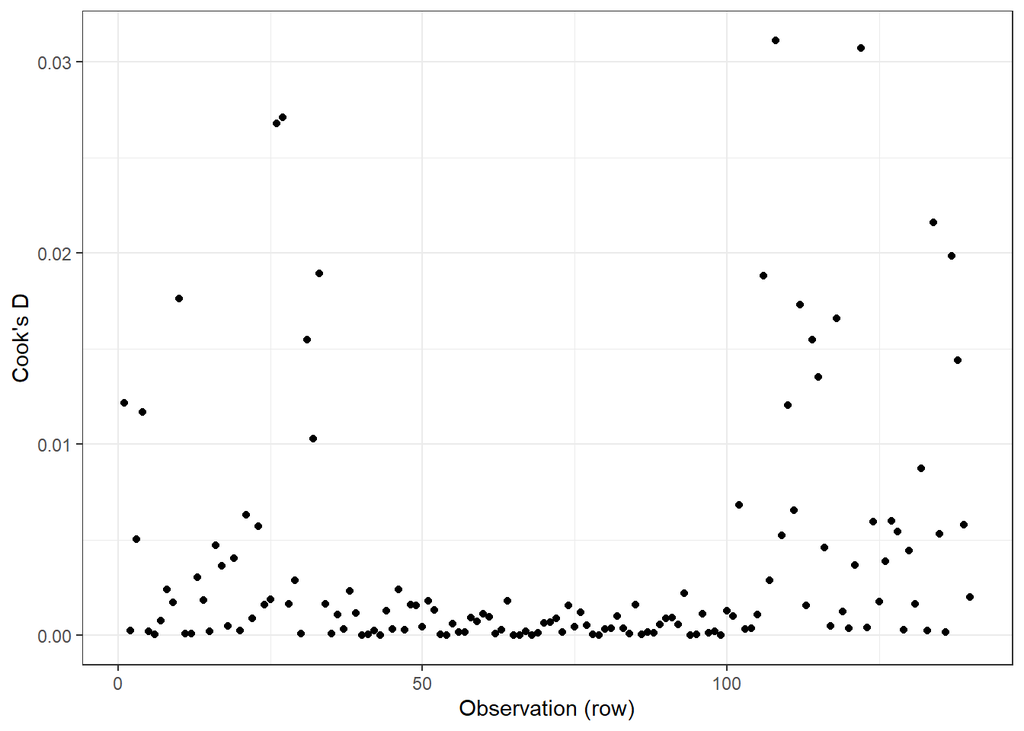

```r
## 2. Cook's D by observation
tibble(row = seq_along(cd_obs), cooksd = cd_obs) |>
  ggplot(aes(x = row, y = cooksd)) +
  geom_point() +
  labs(x = "Observation (row)", y = "Cook's D") +
  theme_bw()
```

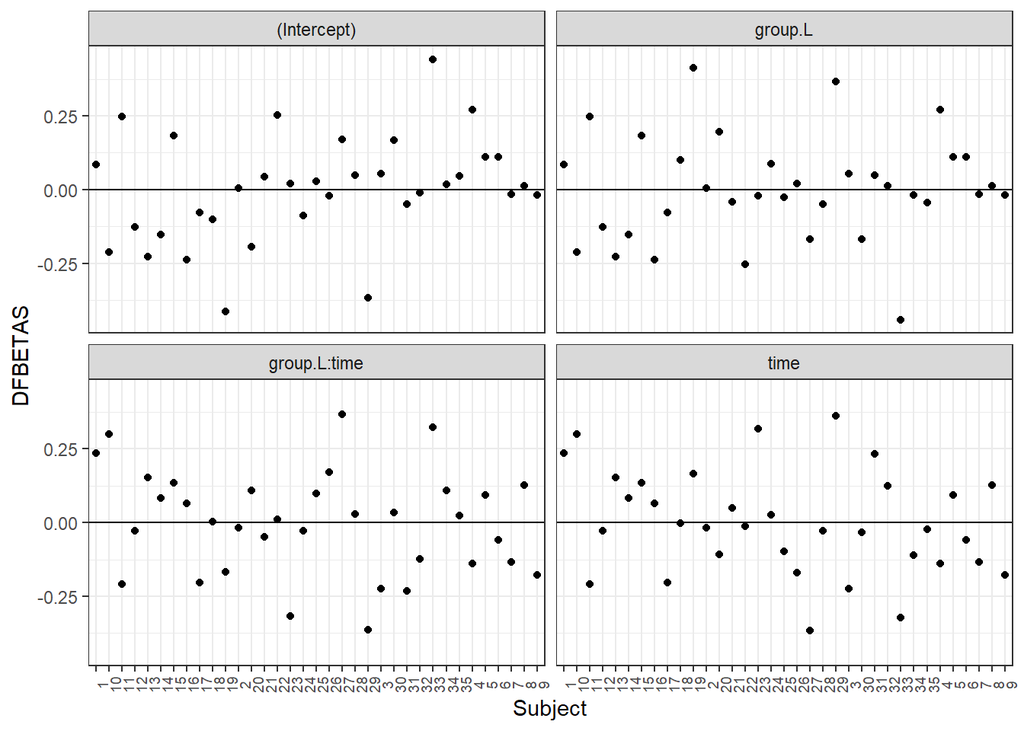

```r
## 3. DFBETAS by subject, one panel per fixed effect
as.data.frame(dfb_subj) |>
  mutate(subID = subj_ids) |>
  pivot_longer(-subID, names_to = "term", values_to = "dfbetas") |>
  ggplot(aes(x = subID, y = dfbetas)) +
  geom_point() +
  geom_hline(yintercept = 0) +
  facet_wrap(~ term) +
  labs(x = "Subject", y = "DFBETAS") +
  theme_bw() +
  theme(axis.text.x = element_text(angle = 90, size = 7))
```

## Summary

- Like other regression models, we have several key assumptions that underpin the validity of our statistical inferences in mixed-effects regression. These are: **additivity and linearity**; **normality of residuals**; **normality of random effects**; and **homoscedasticity** of the residuals.
- Broadly speaking, our models are robust to violations of any one of these assumptions, but our p-value can be very misleading if violation are major or if we have multiple violations at once.
- We also have some important *considerations* (not strictly speaking assumptions) that we want to check: **collinearity** among the fixed-effect predictors and **disproportionate influence** from either individual participants or data points.